# Bodymass Size Spectrum Trends of the Northeastern US

Size distribution patterns across the historic New England fishing grounds.

Adam Kemberling https://github.com/adamkemberling (Gulf of Maine Research Institute)https://gmri.org  
2021-09-30

# History of the Region

The waters of the Northeastern US and nearby Canada have been a center of attention for fisheries and fisheries management for over a century.

Over that period an extensive removal of fishes has occurred, through technologically-evolving fishing practices. Despite management efforts, the catch composition and size-distribution of the fishes present has not recovered to pre-industrial levels.

This document aims to highlight patterns in the modern bodymass-distribution, and provide insight into how the region’s community has responded to these external forces.

All data displayed below comes from the Northeast Groundfish Survey and spans all survey areas from the Mid-Atlantic Bight North to the Gulf of Maine.

## Abundance and Size Trends

### Trends in Abundance

Until around 2015, the abundance of fishes has been on a slow and steady rise. However, much of the rise in abundance has been in individuals smaller than 50cm in length, with the largest increase in the 10-25cm range.

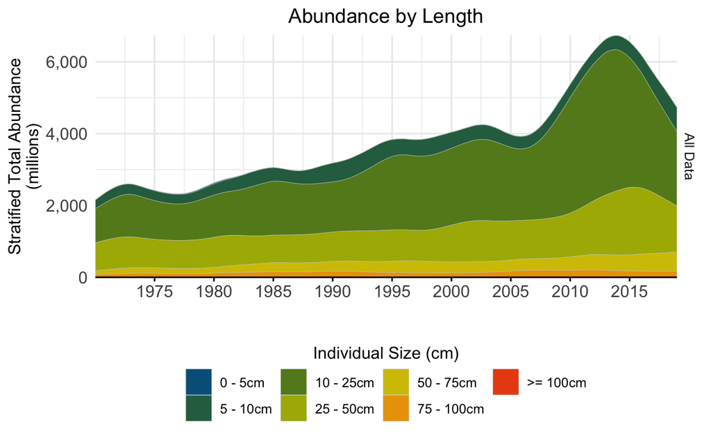

When looking at individual biomasses we see a similar pattern (abundance ~ biomass). Much of that increase in abundance is restricted to individuals weighing less than 0.5kg, with very little transfer of biomass to larger individuals in the population.

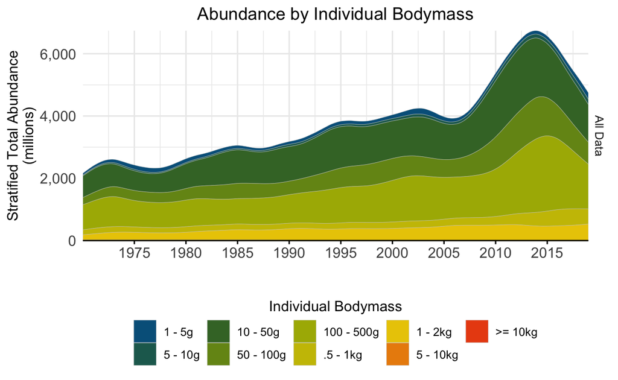

### Trends in Biomass

When we look at the distribution of the overall biomass in the region we can see a similar pattern, but with more clarity on what share of “mass” is held by larger individuals.

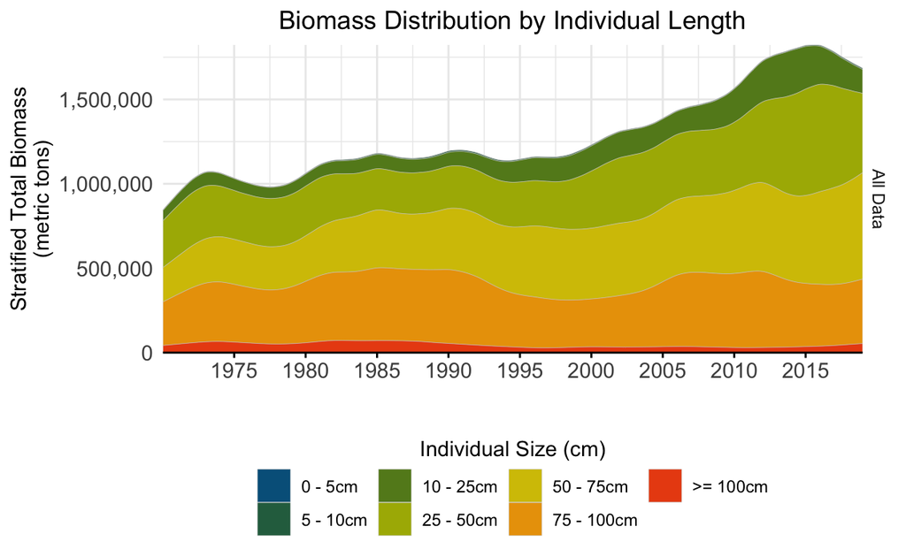

When looking at how the overall biomass of the community is distributed across individual bodymass we can see a widening of the share held by fishes weighing 2kg or less, particularly in the 1-2kg range.

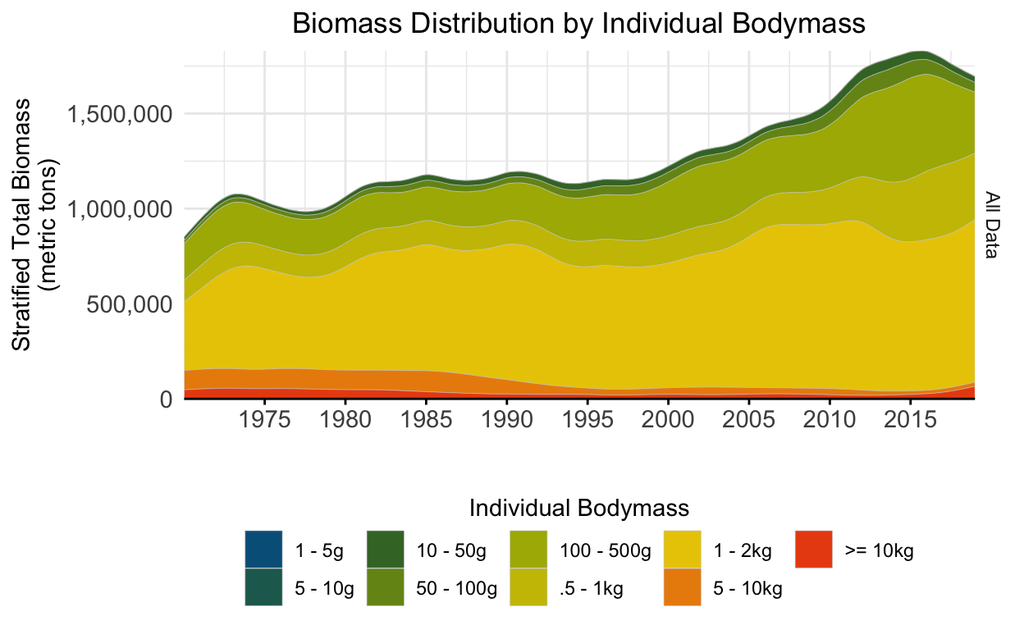

# Fish Removal vs. Growth Suppression

Two non-mutually exclusive explanations for why we don’t see more larger individuals jump to mind when looking at these patterns. The first is that there is some sort of selective pressure that is removing individuals from the population before they can reach the larger sizes they historically had. This could be either fishing pressures or natural mortality from things like predation, or some combination of both. The second is that it is no longer energetically favorable to grow to such larger sizes. This could be explained by a direct impact of temperature making it more energetically costly to reach such sizes, or indirectly through some disruption on the prey they forage on.

## Are Species Getting Smaller?

One thing to look at is whether populations within a species are on-average a smaller size than they were earlier in the timeseries. Another way to have less larger individuals is to have a change in species composition. In that scenario the abundance of smaller species would have increased more than some of the larger species.

**NOTE:** Body size treendds and data are based on area-stratified abundances to reflect the survey design of the survey.

### Changes in Average Size

The size organism that ecosystems can support is related to the productivity and energy transfer within it. Looking it patterns in body size over time can reflect changes in that productivity or the energy transfer dynamics.

### What is the General Direction?

When we look at the trends in average body size for species in each season we can see that a majority of them are trending smaller. Of the trends that show significant trends more than two thirds show a decline in average body size over the years.

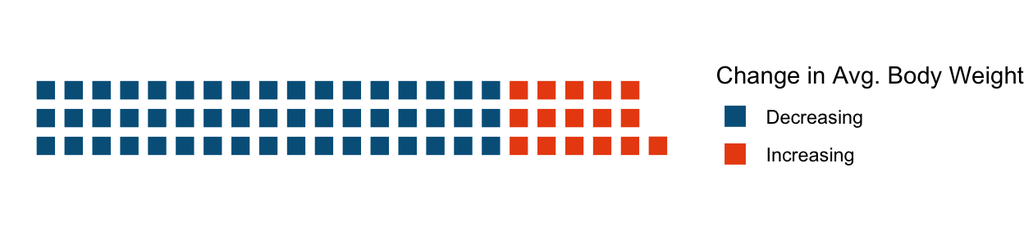

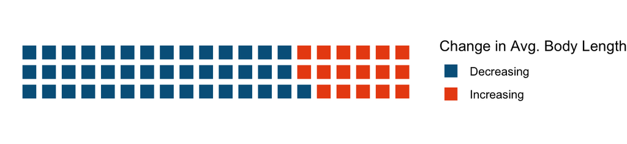

### What Species are Showing Change?

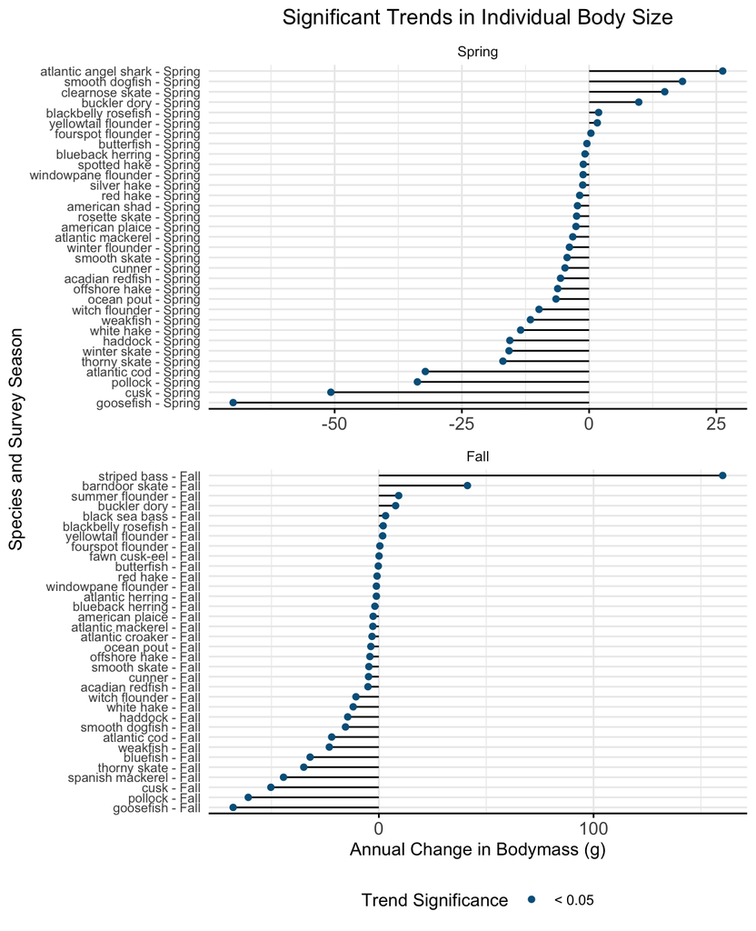

## Body Size Spectrum

Another way to capture the overall body mass distribution within a community is through the body size or body mass spectrum. The body mass spectrum slope is an accounting of the trend between log(abundance) and log(bodymass) of the community.

This relationship is rooted in energy transfer dynamics and the slope of this relationship has been suggested for use as a community index.

The relationship for the full survey area in both body size spectrum slope, and exponent of the individual size distribution (ISD) can be viewed as its own timeline.

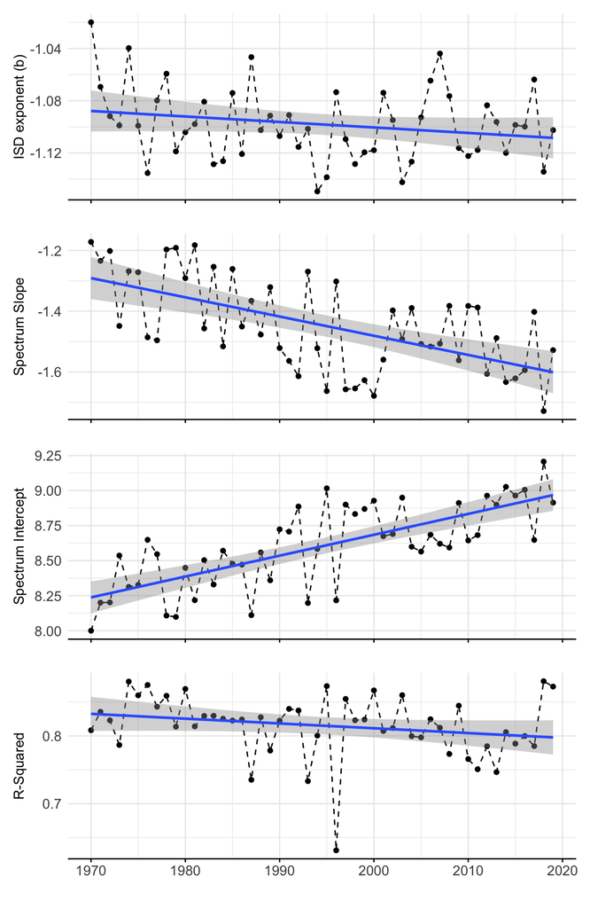

**Diagnostics**

For all years there was a significant linear relationship between normalized log10(abundance) and log10(bodymass). The year with the lowest r-squared was 1996 with an adjusted r-square of 0.63. The underlying data reveals that even for the worst fitting relationship there is a spike in biomass in the middle bins along the full size distribution.

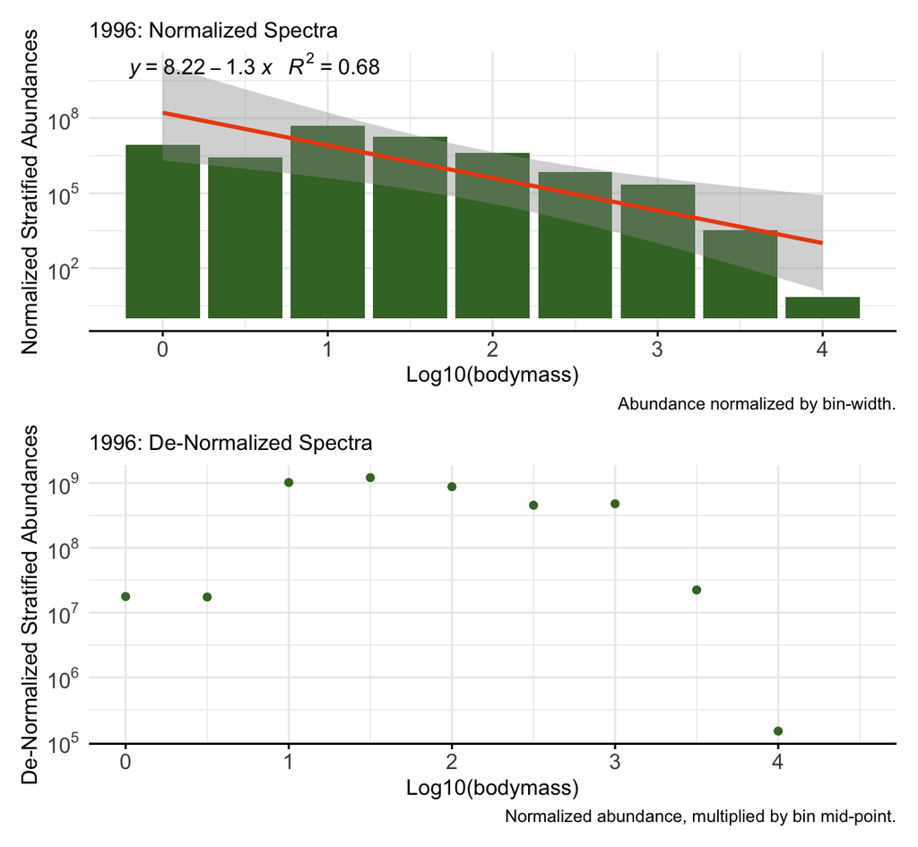

**Changing Over Time**

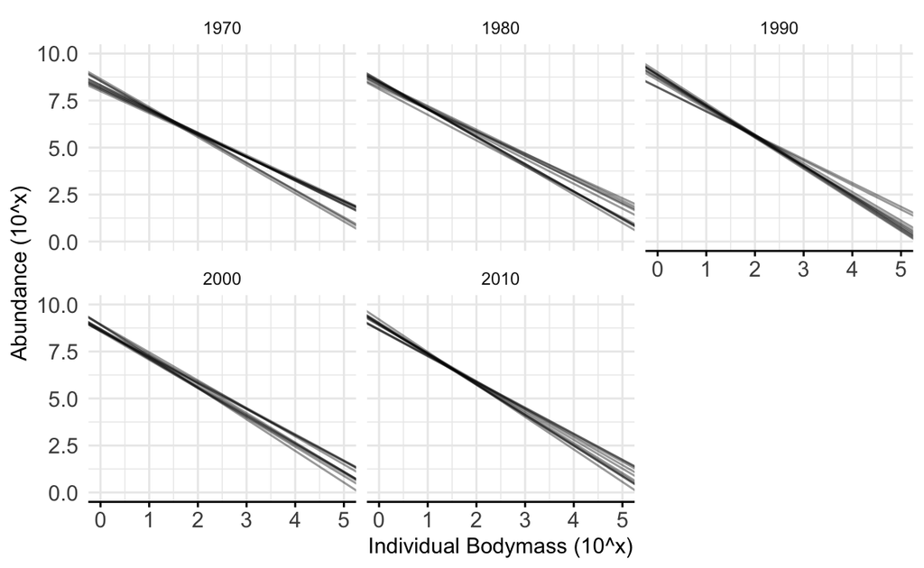

### Overall Breakpoints

It is evident from the slope timeseries that there has been significant changes in spectra slope and intercepts over time. To answer whether a regime change has occurred we can perform a change point analysis.

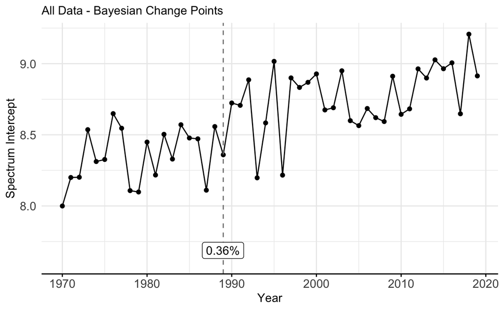

### What Does it Mean?

There is a big interest in using size spectrum slope as an ecological indicator. While methodology for estimating slope exists, whether through regression methods or likelihood methods, it can be difficult/tricky how to interpret.

Here are some statements that have stuck with me:

From Kerr & Dickie:

> Comparative studies among spectra for a number of aquatic environments suggests the major difference between areas is in the level of the intercept and of the spectral lines, and may reflect differences in basic nutrient supply and availability.

From Zoom recording of Axel Rossberg (size spectrum group):

If you do measure slopes: you can see how close you are to different regimes (oligotrophic / eutrophic). These are two extreme and special cases of size spectrum dynamic “solutions”.

In the oligotrophic case the productivity is just right to be able to sustain the minimal power law and sustain a size spectrum.

In the eutrophic case you have a situation where predators are not constrained by prey satiation

**Intuition of Slope & Spectrum Exponents**

The slope of the bodymass spectra reflects the transfer of energy (in the form of biomass) from the smaller -> larger individuals. In this context a steeper slope is indicative of a less efficient energy flux from smaller to larger sized members of the community.

Though this value should be relatively stable through time, steepening over time can be indicative of external factors that would limit this energy transfer.

**Intuition of the Intercept**

The intercept of the bodymass size spectra has been used as an indication of the productivity of a system, with larger intercept values representative of environments with higher overall biomass. This interpretation should be used cautiously as larger intercepts can also be the result of other dynamics (think see-saw).

### Where are We? Top-down vs. Bottom-up

The shape of size spectra are commonly characterized by “domes”. The presence, magnitude, and location on the size-axis of these domes is impacted by both top-down and bottom-up forcing.

From simulation studies it is generally accepted the large-domes result from top-down forcings (at longer time scales).

Simulation studies can also be used to show the impacts of fishing and gear selectivity on the shifting of these domes.

**Do we See Domes?**

One consideration that I have not sorted out, is how to interpret changes to the internal structure of the size spectrum. Primarily the presence/absence or shifting of domes within the size spectra.

Now, when we look at large portions of the data (or all of it), the power-law relationship over-estimates the tails of the spectrum.

This is clear in both the normalized size spectra (abundance / bin-width) and the de-normalized size spectra (normalized abundance * bin mid-point).

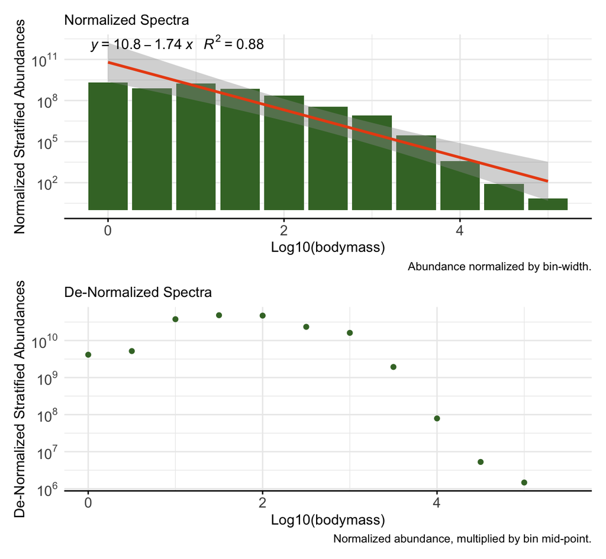

But for each individual year, there is the potential for an independent structure that reflects the abundances of that subset:

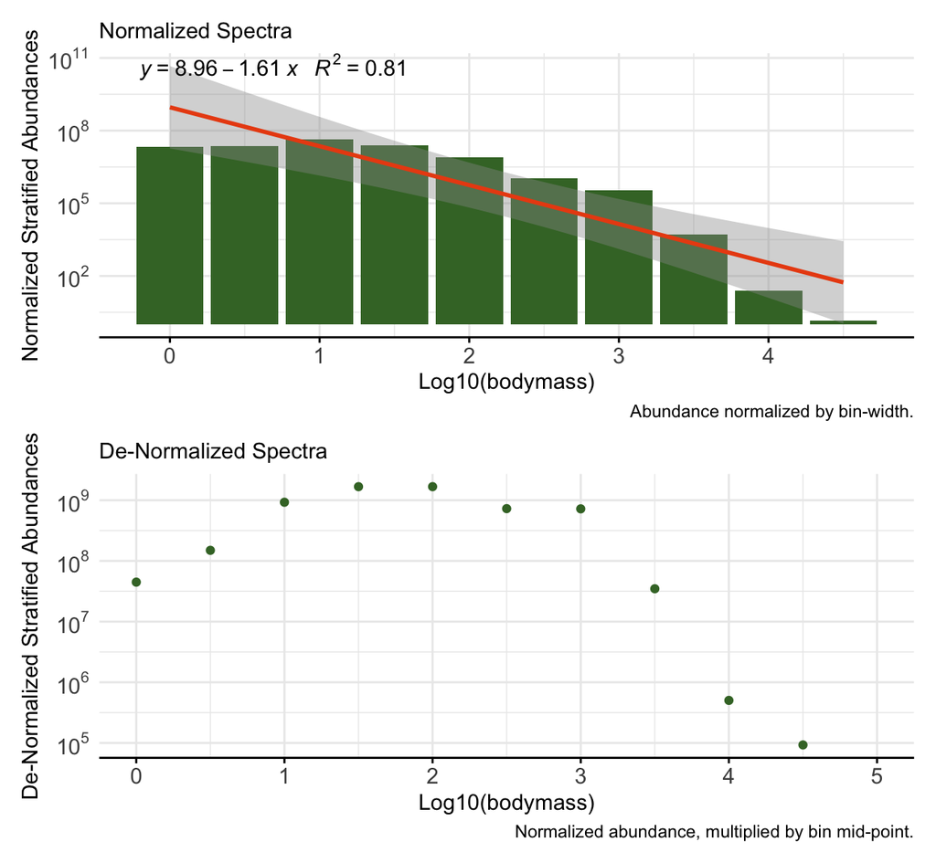